# UD651 - Problem Set 5

Ivan Heneghan

20 January 2016

Load relevant libraries:

```r
library(ggplot2)
library(gridExtra)
library(plyr)
library(dplyr, warn.conflicts = FALSE)
library(alr3)
library(reshape2)
library(tidyr)
library(GGally)
```

1. Histogram of diamond prices, faceted by color; cut used to color the bars

```r
glimpse(diamonds)
```

```
## Observations: 53,940
## Variables: 10
## $ carat   (dbl) 0.23, 0.21, 0.23, 0.29, 0.31, 0.24, 0.24, 0.26, 0.22, ...
## $ cut     (fctr) Ideal, Premium, Good, Premium, Good, Very Good, Very ...
## $ color   (fctr) E, E, E, I, J, J, I, H, E, H, J, J, F, J, E, E, I, J,...
## $ clarity (fctr) SI2, SI1, VS1, VS2, SI2, VVS2, VVS1, SI1, VS2, VS1, S...
## $ depth   (dbl) 61.5, 59.8, 56.9, 62.4, 63.3, 62.8, 62.3, 61.9, 65.1, ...
## $ table   (dbl) 55, 61, 65, 58, 58, 57, 57, 55, 61, 61, 55, 56, 61, 54...
## $ price   (int) 326, 326, 327, 334, 335, 336, 336, 337, 337, 338, 339,...
## $ x       (dbl) 3.95, 3.89, 4.05, 4.20, 4.34, 3.94, 3.95, 4.07, 3.87, ...
## $ y       (dbl) 3.98, 3.84, 4.07, 4.23, 4.35, 3.96, 3.98, 4.11, 3.78, ...
## $ z       (dbl) 2.43, 2.31, 2.31, 2.63, 2.75, 2.48, 2.47, 2.53, 2.49, ...
```

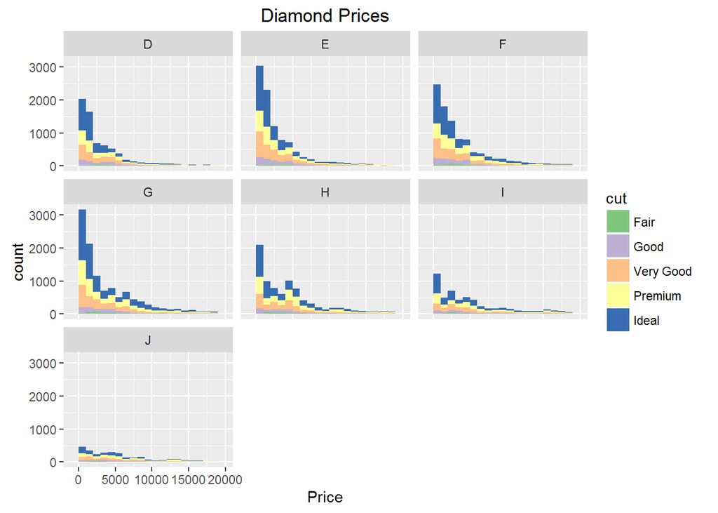

```r
ggplot(data = diamonds, aes(x = price, fill = cut)) +
  geom_histogram(binwidth = 1000) +
  facet_wrap( ~ color) +
  scale_fill_brewer(type = "qual") +
  xlab("Price") +
    ggtitle("Diamond Prices")
```

2. Scatterplot of price v table, colored by cut

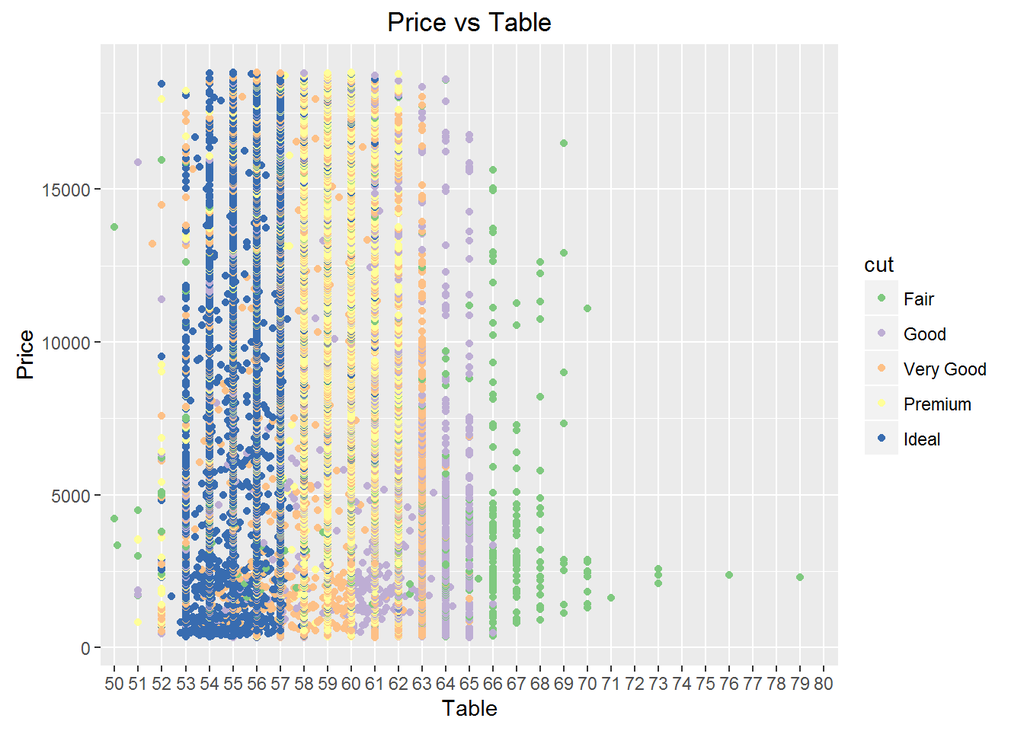

```r
ggplot(data = diamonds, aes(x = table, y = price)) +
  geom_point(aes(color = cut)) +
  coord_cartesian(xlim = c(50, 80)) +
  scale_x_discrete(breaks = seq(50, 80, 1)) +
  scale_color_brewer(type = "qual") +
  xlab("Table") +
  ylab("Price") +
  ggtitle("Price vs Table")
```

3a. Create volume variable

```r
diamonds$volume = diamonds$x * diamonds$y *diamonds$z
```

3b. Scatterplot!

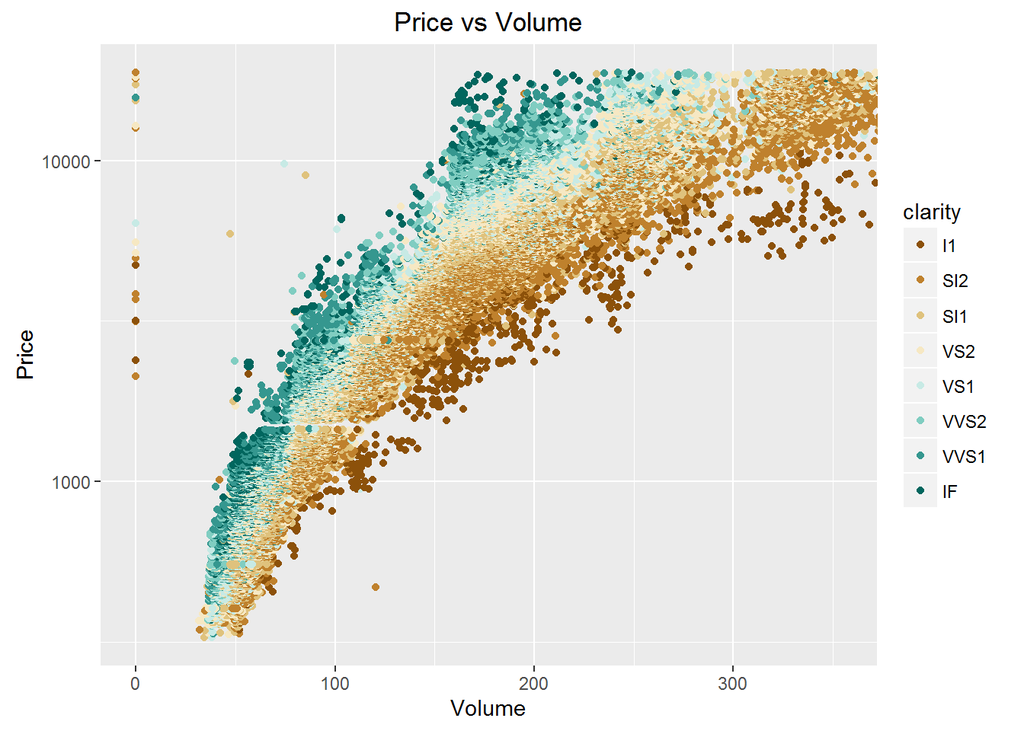

```r
ggplot(data = diamonds, aes(x = volume, y = price)) +
  geom_point(aes(color = clarity)) +
  coord_cartesian(xlim = c(0, quantile(diamonds$volume, 0.99))) +
  scale_y_log10() +
  scale_color_brewer(type = "div") +
  xlab("Volume") +
  ylab("Price") +
  ggtitle("Price vs Volume")
```

4. Proportion of friendships initiated

4a. Create prop_initiated

```r
pf <- read.csv("pseudo_facebook.tsv", sep = "\t")
pf$prop_initiated <- ifelse(pf$friend_count > 0, c(pf$friendships_initiated/pf$friend_count), 0)
```

4b. Line graph of median prop vs tenure; color by year_joined.bucket

4bi. Year joined & year joined bucket

```r
pf$year_joined <- floor(2014 - ceiling(pf$tenure/365))
pf$year_joined.bucket <- cut(pf$year_joined, c(2004, 2009, 2011, 2012, 2014))
```

4bii. Graphing

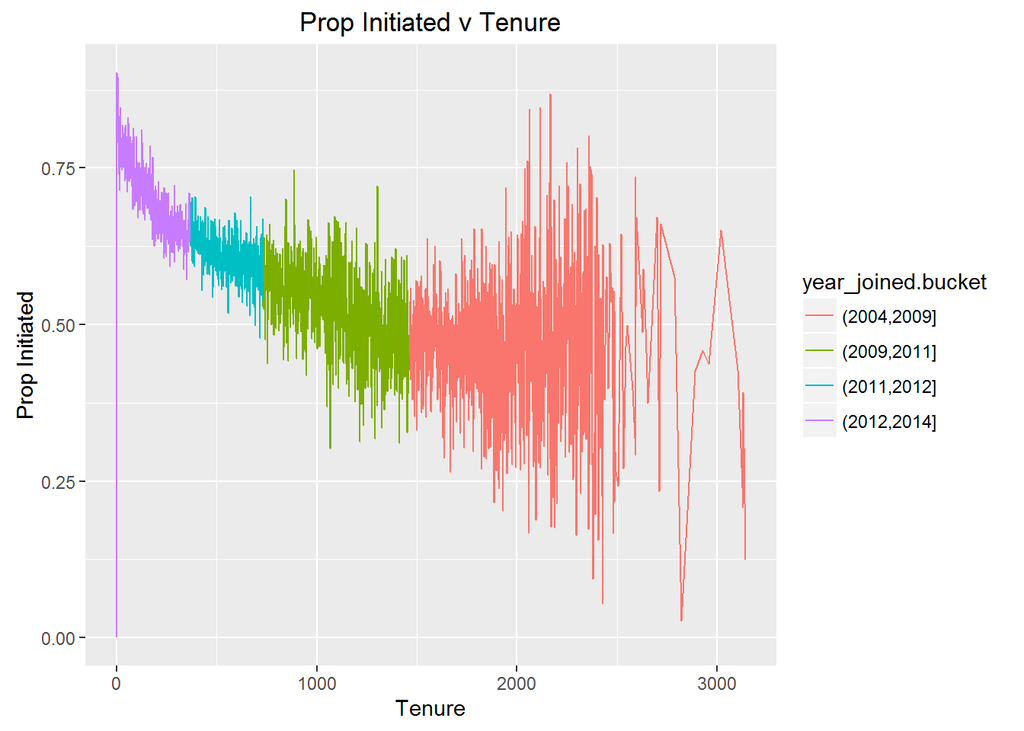

```r
ggplot(aes(x = tenure, y = prop_initiated),
       data = subset(pf, !is.na(year_joined.bucket))) +
  geom_line(aes(color = year_joined.bucket), stat = "summary", fun.y = median) +
  xlab("Tenure") +
  ylab("Prop Initiated") +
  ggtitle("Prop Initiated v Tenure")
```

4biii. Smooth the plot

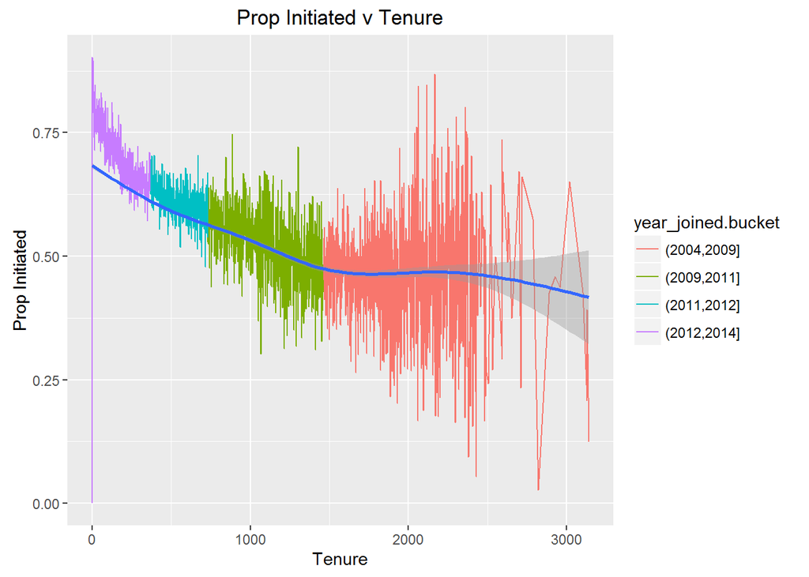

```r
ggplot(aes(x = tenure, y = prop_initiated),
       data = subset(pf, !is.na(year_joined.bucket))) +
  geom_line(aes(color = year_joined.bucket), stat = "summary", fun.y = median) +
  geom_smooth() +
  xlab("Tenure") +
  ylab("Prop Initiated") +
  ggtitle("Prop Initiated v Tenure")
```

4biv.Summary

```r
summary(subset(pf$prop_initiated, pf$year_joined > 2012 & pf$year_joined <= 2014))
```

```
##    Min. 1st Qu.  Median    Mean 3rd Qu.    Max.
##  0.0000  0.5000  0.6912  0.6430  0.8438  1.0000
```

5. Scatterplot of price/carat ratio

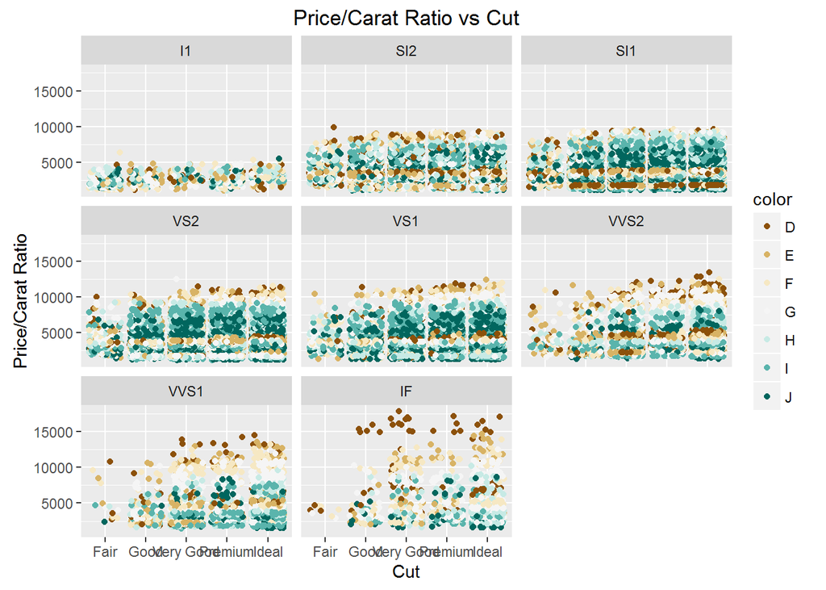

```r
ggplot(data = diamonds, aes(x = cut, y = price/carat)) +
  geom_point(aes(color = color), position = position_jitter(h = 0)) +
  facet_wrap( ~ clarity) +
  #coord_cartesian(xlim = c(0, quantile(diamonds$volume, 0.99))) +
  #scale_y_log10() +
  scale_color_brewer(type = "div") +
  xlab("Cut") +
  ylab("Price/Carat Ratio") +
  ggtitle("Price/Carat Ratio vs Cut")
```

6. Gapminder revisited - Mobile phone ownership & income per person/GDP per capita, layer in hourly pay.

6a. Import data

```r
cell <- read.csv("cell phone per 100.csv", 1, stringsAsFactors = FALSE)
gdp <- read.csv("GDPpercapitaconstant2000US.csv", 1, stringsAsFactors = FALSE)
hourly <- read.csv("indicator_hour compensation.csv", 1, stringsAsFactors = FALSE)
```

6b. Clean up cell data

```r
names(cell)[1] <- c("country")
cell <- cell %>% gather(year, subs, -country)
cell$year <- gsub("X", "", cell$year)
```

6c. Clean up gdp data

```r
names(gdp)[1] <- c("country")
gdp <- gdp %>% gather(year, gdp, -country)
gdp$year <- gsub("X", "", gdp$year)
```

6d. Clean up hourly data

```r
names(hourly)[1] <- c("country")
hourly <- hourly %>% gather(year, hourly, -country)
hourly$year <- gsub("X", "", hourly$year)
```

6e. Subset to a matching timeframe - 1981 to 2006

```r
cell <- subset(cell, year >= 1981 & year <= 2006)
gdp <- subset(gdp, year >= 1981 & year <= 2006)
hourly <- subset(hourly, year >= 1981 & year <= 2006)
```

6f. Merge data sets

```r
temp <- merge(cell, gdp, all = TRUE)
merged <- merge(temp, hourly, all = TRUE)
```

6g. Clean NAs

```r
merged <- filter(merged, !is.na(merged$subs))
merged <- filter(merged, !is.na(merged$gdp))
merged <- filter(merged, !is.na(merged$hourly))
```

6h. Coerce year to numeric

```r
merged$year <- as.numeric(merged$year)
```

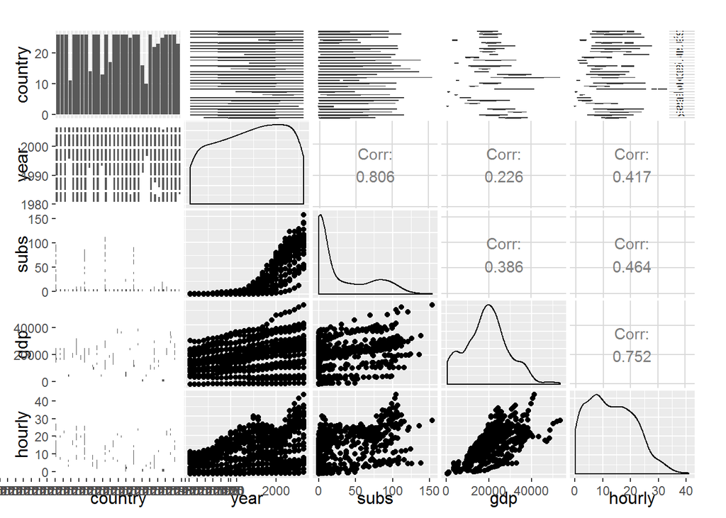

```r
ggpairs(merged)
```

6j. Line graph showing evolution of hourly rate over time, and mean/quantiles for 10th/50th/90th

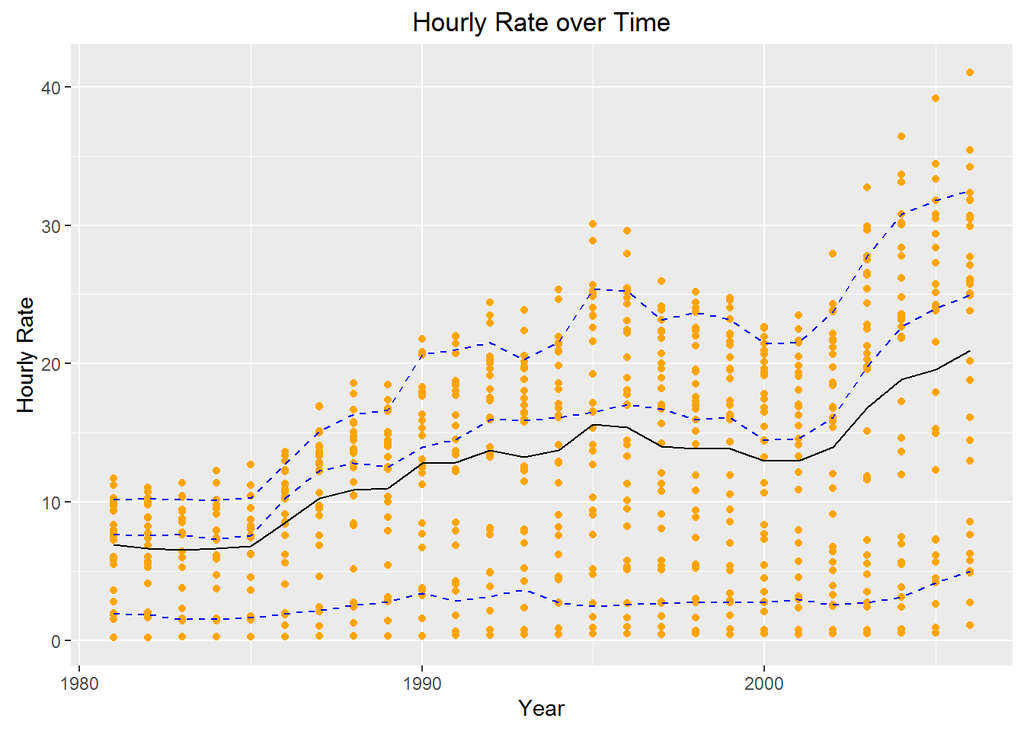

```r
ggplot(aes(x = year, y = hourly), data = merged) +
  geom_point(color = "orange") +
  geom_line(stat = "summary", fun.y = mean) +
  geom_line(stat = "summary", fun.y = quantile, fun.args = list(probs = .1), linetype = 2, color = "blue") +
  geom_line(stat = "summary", fun.y = quantile, fun.args = list(probs = .5), linetype = 2, color = "blue") +
  geom_line(stat = "summary", fun.y = quantile, fun.args = list(probs = .9), linetype = 2, color = "blue") +
  xlab("Year") +
  ylab("Hourly Rate") +
  ggtitle("Hourly Rate over Time")
```

6k. Line graph showing evolution of subs over time, and mean/quantiles for 10th/50th/90th

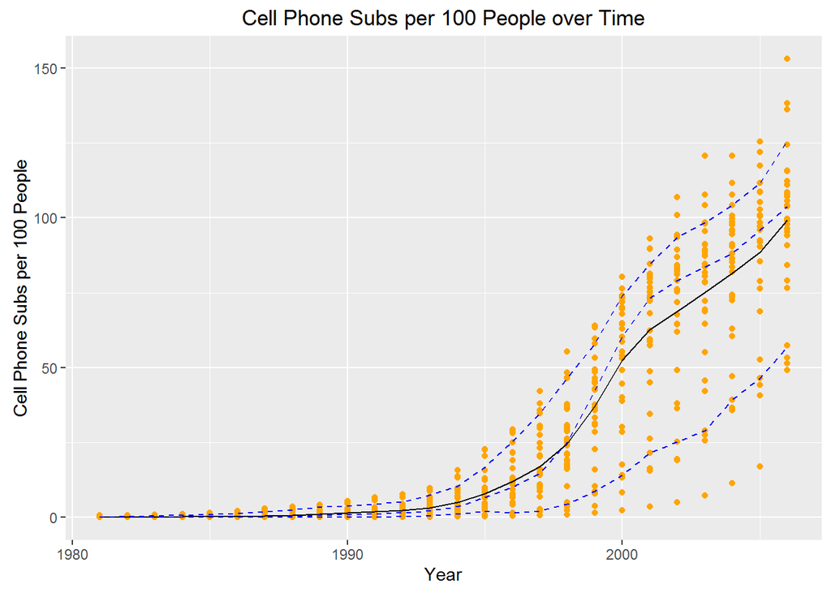

```r
ggplot(aes(x = year, y = subs), data = merged) +
  geom_point(color = "orange") +
  geom_line(stat = "summary", fun.y = mean) +
  geom_line(stat = "summary", fun.y = quantile, fun.args = list(probs = .1), linetype = 2, color = "blue") +
  geom_line(stat = "summary", fun.y = quantile, fun.args = list(probs = .5), linetype = 2, color = "blue") +
  geom_line(stat = "summary", fun.y = quantile, fun.args = list(probs = .9), linetype = 2, color = "blue") +
  xlab("Year") +
  ylab("Cell Phone Subs per 100 People") +
  ggtitle("Cell Phone Subs per 100 People over Time")
```

6l. By country, ratio of subs/gdp evolution - massive uptick in some countries (Philippines, Hungary, Brazil, Poland)

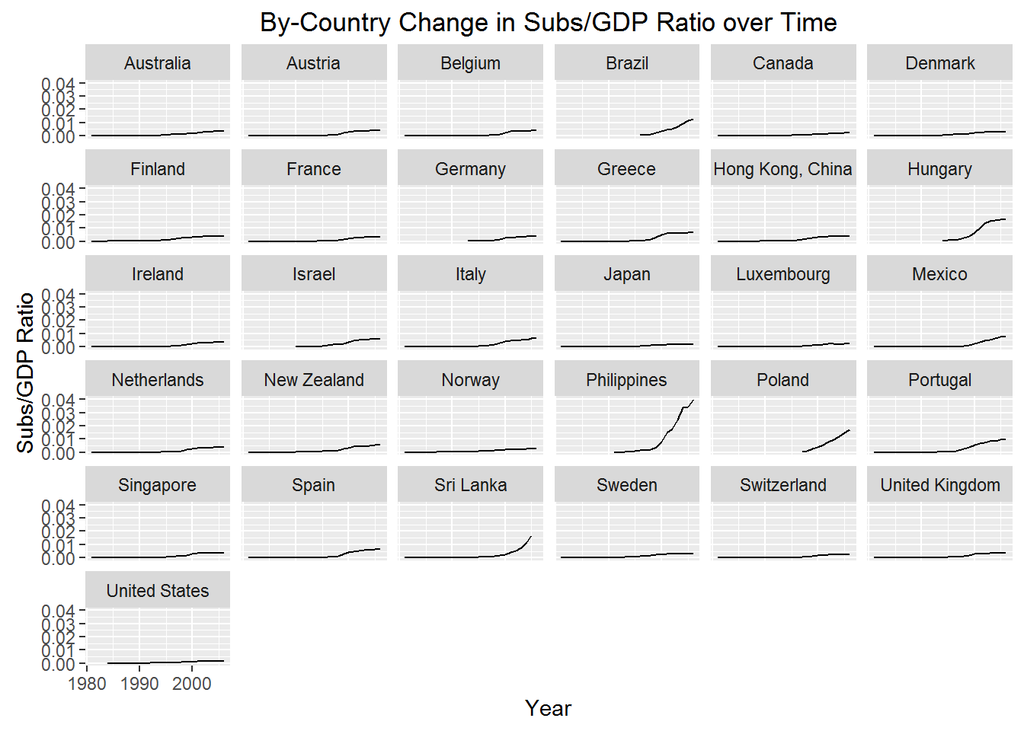

```r
ggplot(aes(x = year, y = subs/gdp), data = merged) +
  geom_line() +
  facet_wrap( ~ country) +
  xlab("Year") +
  ylab("Subs/GDP Ratio") +
  ggtitle("By-Country Change in Subs/GDP Ratio over Time")
```

6m. Look at which countries means are increasing faster than the grand mean of the ratio, zooming in on 1995 to 2006 - 8 in total. Is this the right approach, as removing first mean calculations doesn’t change the graph at all?

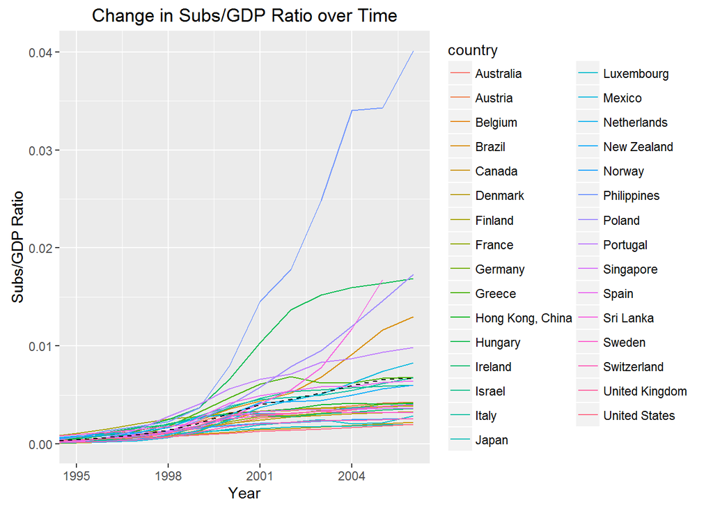

```r
ggplot(aes(x = year, y = subs/gdp), data = merged) +
  geom_line(aes(color = country, group = country), stat = "summary", fun.y = mean) +
  geom_line(stat = "summary", fun.y = mean, linetype = 2, color = "black") +
  coord_cartesian(xlim = c(1995, 2006)) +
  xlab("Year") +
  ylab("Subs/GDP Ratio") +
  ggtitle("Change in Subs/GDP Ratio over Time")
```

6n. Heatmap

[figure not shown]

```r
ggplot(aes(x = year, y = gdp, fill = subs), data = merged) +
  geom_tile() +
  scale_fill_gradientn(colors = colorRampPalette(c("blue", "red"))(100))
```